# Прохождении 1 этапа внешних курсов

Введение

Киселева Елизавета Александровна

Российский университет дружбы народов, Москва, Россия

17.05.25

# Информация

## Докладчик

- Киселева Елизавета Александровна, НКАбд-02-24
- Студентка факультета физико-математических и естественных наук
- Российский университет дружбы народов
- 1132246735
- https://github.com/liza11223/site-project.git
- https://liza11223.github.io/site-project/
- https://github.com/liza11223/study_2024-2025_os-intro.git

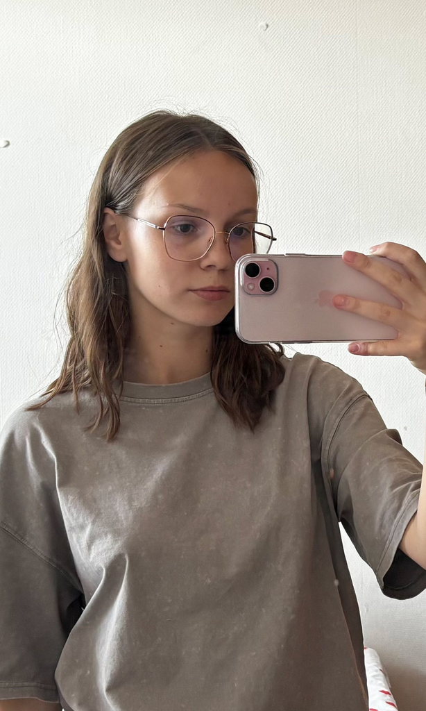

## Цель работы

Ознакомиться с функционалом операционной системы Linux.

## Задание

Просмотреть видео и на основе полученной информации пройти тестовые задания.

## Теоретическое введение

Linux (GNU/Linux) — семейство Unix-подобных ОС на базе ядра Linux с утилитами проекта GNU. Распространяются в основном бесплатно как дистрибутивы, включающие системные и прикладные компоненты (свободные и проприетарные).

# Выполнение лабораторной работы

## Этап 1 (часть 1)

[figure not shown]

Задание 1

Курс называется “Введение в Linux” — без ошибок.

[figure not shown]

Задание 2

Прочитав критерии, я выбрала правильные утверждения.

[figure not shown]

Задание 3

У меня установлена Windows.

[figure not shown]

Задание 4

Мы использовали VirtualBox для запуска другой ОС.

[figure not shown]

Задание 5

Я запустила Linux на виртуальной машине и основном ноутбуке.

[figure not shown]

Задание 6

Я создала документ, сохранила его и прикрепила к курсу.

[figure not shown]

Задание 7

deb — формат пакетов для Debian и Ubuntu.

[figure not shown]

Задание 8

[figure not shown]

Задание 8

Изучила медиапроигрыватель и записала автора.

[figure not shown]

Задание 9

Менеджер обновлений устанавливает апдейты безопасности.

[figure not shown]

Задание 10

Термин — определение. Ассоль — имя героини.

[figure not shown]

Задание 11

CLI Linux — регистрозависимая.

[figure not shown]

Задание 12

Корректный вариант команды — с правильным регистром.

[figure not shown]

Задание 13

Прописала полный путь до директории Downloads.

[figure not shown]

Задание 14

`rm -r` — удаление папки и её содержимого.

[figure not shown]

Задание 15

Проверила результат в ходе работы.

[figure not shown]

Задание 16

Запуск в фоновом режиме.

[figure not shown]

Задание 17

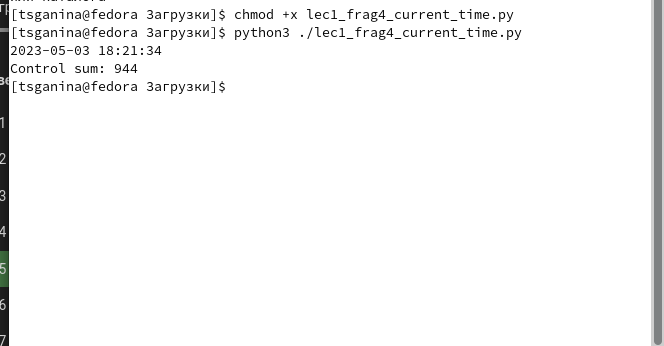

Задание 17

Выполнение команды.

[figure not shown]

Задание 18

Ошибки выводятся на экран. Для вывода в файл — перенаправление.

[figure not shown]

Задание 19

Различные способы перенаправления потоков (stdout, stderr).

[figure not shown]

Задание 20

Пример перенаправлений и использования конвейеров.

[figure not shown]

Задание 21

Ключ `-O` указывает имя сохраняемого файла.

[figure not shown]

Задание 22

Ключ `-q` отключает вывод wget.

[figure not shown]

Задание 23

Ограничение загрузки определёнными типами файлов с помощью `-A`.

[figure not shown]

Задание 24